# Data Visualization in R - Course Diary

Miikka Turkkila

2021

# Introduction

This is my course diary for the University of Helsinki course Data Visualization in R for PhD students. I’ll use this diary to record (mainly for myself) my progress on the course by including relevant exercises and assessments. Additionally I hope to use this diary to facilitate my own reflections and thoughts about data visualization more generally.

Below are my previous experience and expectations for the course. This was part of home assignment on the first lecture.

## Previous experience

Courses on:

- Basics of programming (Java)
- Scientific computing (Python, Matlab and C)
- Introduction to Open Data Science (R)
- Machine learning (Python)

Additionally, I have done two simple online tools with Javascript that are used in research and in teaching. Actually, my lesson observation tool includes simple timeline visualization of observations that is drawn on HTML-canvas using only Javascript. It was rather interesting to figure out how to draw axes, ticks, labels and the data with just canvas methods.

I have mainly used Python in my analyzes and data visualization (Master’s thesis, two articles and few posters etc.). I plan to use R more in the future.

## Expectations

I think I have quite good basic understanding of data visualization, but through this course I hope to refine and expand my knowledge and skills. I want to practice and become more proficient with R and ggplot2 as those have some benefits over Python. Additionally, there are some nice network analysis packages for R that I might need to use in the future.

# Week 1

The first week had only three very basic exercises with base R and I completed with one simple r-script file. Thus, the first week exercises are not included in this course diary. However, I did set up [github repository](https://github.com/MTurkkila/datavisR) and this course diary webpage. Additionally, I loaned the course book *Data Visualization: A Practical Introduction* by Kieran Healy and *The functional art: : An introduction to information graphics and visualization* by Alberto Cairo. At a glance both seem interesting and useful.

## Reflection

Unfortunately I missed first week lecture and exercise session as I was unaware I was accepted to the course. Foolishly I thought i would get notification via email, but Sisu is not smart enough system for that. I did go through the lecture slides and seemed that the content was interesting and engaging so I’m really disappointed I did not get to hear the lecture. Luckily, the first exercises were quick and easy so missing the first exercise session is not too worrisome.

Overall, I have the feeling I will like this course and will learn something new.

# Week 2

## Exercise 1

### 1.1

Create a new code chunk where you load the tidyverse package. In the chunk settings, suppress any output messages.

```r
library(tidyverse)
```

### 1.2

The tibble *df* has 60 observations (rows) of variables (columns) group, gender, score1 and score2 (continuous scores from two tests). Each row represents one participant.

```r
df
```

```
## # A tibble: 60 × 4
##    group gender score1 score2
##    <int> <chr>   <dbl> <chr>
##  1     2 F        18.7 14.7563711082321
##  2     1 M        20.1 15.1463059324341
##  3     2 F        17.4 19.0025387614538
##  4     1 M        18.7 15.5693261509451
##  5     2 F        18.5 16.7322250273729
##  6     1 999      16.9 16.4511010915052
##  7     2 M        20.4 15.1008590050657
##  8     1 F        20.3 15.191041952879
##  9     1 F        19.4 13.9717194882152
## 10     2 M        21.2 22.6918520246433
## # … with 50 more rows
```

There is something to fix in three of the variables. Explore the data and describe what needs to be corrected.

**Hint**: You can use e.g. str(), distinct(), and summary() to explore the data.

```r
str(df)
```

```
## tibble [60 × 4] (S3: tbl_df/tbl/data.frame)
##  $ group : int [1:60] 2 1 2 1 2 1 2 1 1 2 ...
##  $ gender: chr [1:60] "F" "M" "F" "M" ...
##  $ score1: num [1:60] 18.7 20.1 17.4 18.7 18.5 ...
##  $ score2: chr [1:60] "14.7563711082321" "15.1463059324341" "19.0025387614538" "15.5693261509451" ...
```

```r
summary(df)
```

```
##      group        gender              score1         score2
##  Min.   :1.0   Length:60          Min.   :14.17   Length:60
##  1st Qu.:1.0   Class :character   1st Qu.:16.85   Class :character
##  Median :1.5   Mode  :character   Median :17.61   Mode  :character
##  Mean   :1.5                      Mean   :17.89
##  3rd Qu.:2.0                      3rd Qu.:19.01
##  Max.   :2.0                      Max.   :21.53
```

```r
distinct(df, gender)
```

```
## # A tibble: 3 × 1
##   gender
##   <chr>
## 1 F
## 2 M
## 3 999
```

*group* could be categorical/factors, *gender* includes values of 999 and *score2* is character-type instead of numeric.

## Exercise 2

### 2.1

Make the corrections you described above.

```r
# Factorize group
df<- df %>% mutate(group = as.factor(group))

# Replace 999 with NA (not available)
df <- df %>% mutate(gender = na_if(gender, 999))

# Change score to numeric
df <- df %>% mutate(score2 = as.numeric(score2))

# Check structure again and distinct groups
df %>% str()
```

```
## tibble [60 × 4] (S3: tbl_df/tbl/data.frame)
##  $ group : Factor w/ 2 levels "1","2": 2 1 2 1 2 1 2 1 1 2 ...
##  $ gender: chr [1:60] "F" "M" "F" "M" ...
##  $ score1: num [1:60] 18.7 20.1 17.4 18.7 18.5 ...
##  $ score2: num [1:60] 14.8 15.1 19 15.6 16.7 ...
```

```r
df %>% distinct(gender)
```

```
## # A tibble: 3 × 1
##   gender
##   <chr>
## 1 F
## 2 M
## 3 <NA>
```

### 2.2

Count observations by group and gender. Arrange by the number of observations (ascending).

```r
df %>% count(group, gender, name ="observations") %>% arrange(observations) # add column name for observations
```

```
## # A tibble: 6 × 3
##   group gender observations
##   <fct> <chr>         <int>
## 1 2     <NA>              1
## 2 1     <NA>              3
## 3 1     F                13
## 4 1     M                14
## 5 2     M                14
## 6 2     F                15
```

## Exercise 3

### 3.1

Create a new variable, **score_diff**, that contains the difference between score1 and score2.

```r
# New variable score_diff into the dataframe with absolute value between score1 and score2
df$score_diff <- abs(df$score1-df$score2)
```

### 3.2

Compute the means of score1, score2, and score_diff.

**Hint**: Like mutate(), summarise() can take multiple variables in one go.

```r
df %>% summarise(score1_mean = mean(score1), score2_mean = mean(score2), score_diff_mean = mean(score_diff))
```

```
## # A tibble: 1 × 3
##   score1_mean score2_mean score_diff_mean
##         <dbl>       <dbl>           <dbl>
## 1        17.9        16.1            2.40
```

### 3.3

Compute the means of score1, score2, and score_diff **by gender**.

```r
df %>% group_by(gender) %>% summarise(mean(score1), mean(score2), mean(score_diff))
```

```
## # A tibble: 3 × 4
##   gender `mean(score1)` `mean(score2)` `mean(score_diff)`
##   <chr>           <dbl>          <dbl>              <dbl>
## 1 F                17.9           16.3               2.29
## 2 M                18.1           16.0               2.53
## 3 <NA>             16.4           15.0               2.28
```

## Exercise 4

### 4.1

Using ggplot2, create a scatter plot with score1 on the x-axis and score2 on the y-axis.

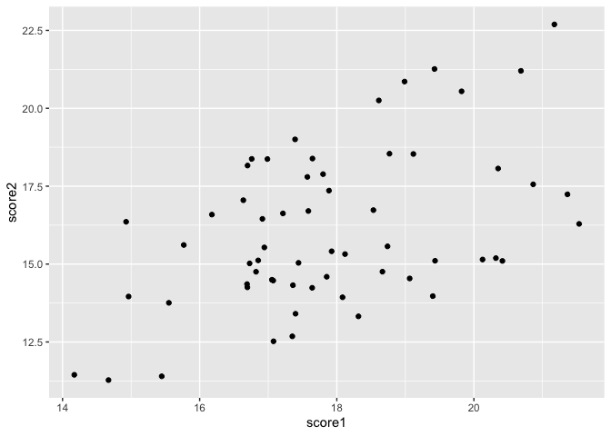

```r
df %>% ggplot(aes(x=score1, y=score2)) + geom_point()
```

### 4.2

Continuing with the previous plot, colour the points based on gender. Set the output figure width to 10 and height to 6.

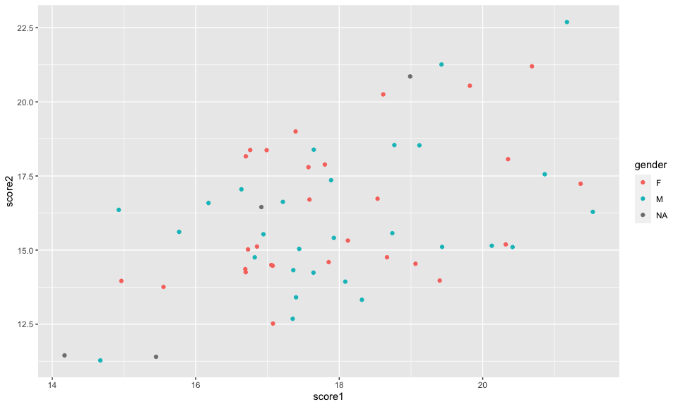

```r
df %>% ggplot(aes(x=score1, y=score2, color=gender)) + geom_point()
```

## Exercise 5

### 5.1

Add the author (your name) and date into the metadata section. Create a table of contents.

### 5.2

Knit your document to HTML by changing `html_notebook` to `html_document` in the metadata, and pressing Knit.

Did these for the returned ex-file!

# Week 3

```r
library(ggplot2)
library(tidyverse)
library(forcats)
```

## Exercise 1

### 1.1

Read the *region_scores.csv* data into R. It should have 240 observations of 6 variables.

```r
df <- read_csv("region_scores.csv")
#Convert education to factorial
df <- df %>% mutate(education = as.factor(education))
df %>% summary #check summary of the data
```

```
##        id            region          education    gender
##  Min.   :  1.00   Length:240         1:85      Length:240
##  1st Qu.: 60.75   Class :character   2:77      Class :character
##  Median :120.50   Mode  :character   3:78      Mode  :character
##  Mean   :120.50
##  3rd Qu.:180.25
##  Max.   :240.00
##       age            score
##  Min.   :19.00   Min.   : 4.269
##  1st Qu.:34.00   1st Qu.:10.282
##  Median :41.00   Median :13.341
##  Mean   :40.17   Mean   :14.056
##  3rd Qu.:48.00   3rd Qu.:17.453
##  Max.   :62.00   Max.   :27.719
```

### 1.2

Cut the continuous variable **age** into a categorical variable **age_group** that has groups of width 10. Use ggplot2’s cutting function.

Count observations by age group.

```r
df <- df %>% mutate(age_group = cut_width(age, 10))
df %>% count(age_group)
```

```
## # A tibble: 5 × 2
##   age_group     n
##   <fct>     <int>
## 1 [15,25]      28
## 2 (25,35]      46
## 3 (35,45]      87
## 4 (45,55]      66
## 5 (55,65]      13
```

## Exercise 2

The chunk below is supposed to produce a plot but it has some errors.

The figure should be a scatter plot of **age** on the x-axis and **score** on the y-axis, with points coloured by **education level** (3 levels). It should also have three linear regression lines, one for each of the education levels.

Fix the code to produce the right figure.

What happens if you use `geom_jitter()` instead of `geom_point()`?

`Jitter` seems to give some random variation or noise. This is confirmed by ggplot documentation.

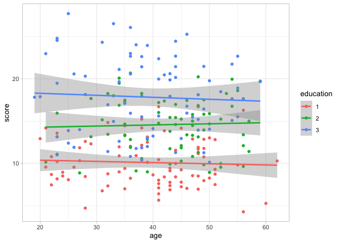

```r
df %>%
  ggplot(aes(x = age, y = score, color = education)) + geom_point() +
  geom_smooth(method = "lm") +
  theme_light()
```

## Exercise 3

### 3.1

Calculate the mean, standard deviation (sd), and number of observations (n) of **score by education and age group**. Also calculate the standard error of the mean (by using sd and n). Save these into a new data frame (or tibble) named edu_age_stats.

```r
edu_age_stats <- df %>% group_by(education, age_group) %>% summarise(mean_score=mean(score), sd_score=sd(score), n=n())
# Compute standard error of mean as sd/sqrt(n)
edu_age_stats$se_score = edu_age_stats$sd_score/sqrt(edu_age_stats$n)
```

### 3.2

Using edu_age_stats, plot a bar plot that has **age group** on the x-axis, **mean score** on the y-axis, and **education levels** in subplots (facets).

Use `geom_errorbar()` to add error bars that represent standard errors of the mean.

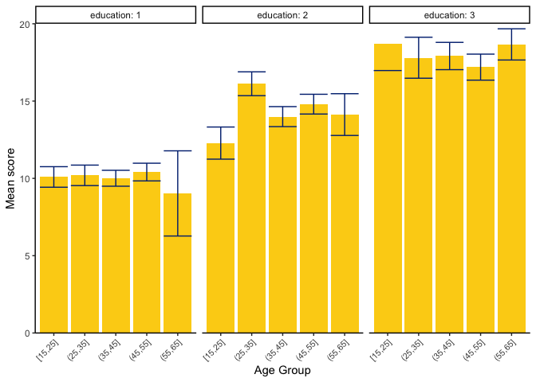

```r
edu_age_stats %>% ggplot(aes(x = age_group, y = mean_score)) +
  facet_wrap("education", labeller = "label_both") +
  geom_col(fill = "#fcd116") + # Color of our faculty for fun
  geom_errorbar(aes(ymin=mean_score-se_score, ymax=mean_score+se_score), colour = "#002b7f") +
  theme_classic() +
  theme(axis.text.x = element_text(angle = 45, hjust = 1, size = 8)) +
  scale_y_continuous(name = "Mean score", expand = c(0, 0), limits = c(0, 20)) +
  scale_x_discrete(name = "Age Group")
```

## Exercise 4

### 4.1

Create a figure that has boxplots of **score** (x-axis) by **region** (y-axis).

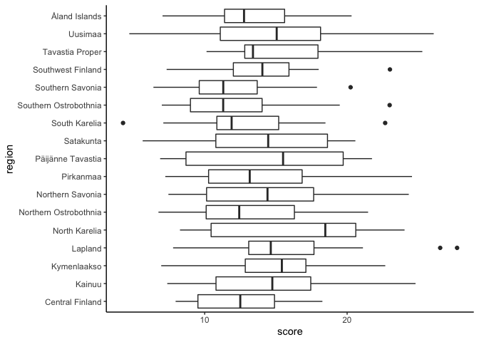

```r
df %>% ggplot(aes(x = score, y = region)) + geom_boxplot() + theme_classic()
```

### 4.2

Group the data by region and add mean score by region to a new column **mean_score**. Do this with **`mutate()`** (not `summarise()`).

Reorder the levels of region based on mean_score.

```r
df <- df %>% group_by(region) %>% mutate(mean_score=mean(score)) %>% ungroup()
df$region <- fct_reorder(df$region, df$mean_score, min)
```

## Exercise 5

Using the data you modified in exercise 4.2, plot **mean scores** (x-axis) by **region** (y-axis) as points. The regions should be ordered by mean score.

Use `stat_summary()` to add error bars that represent standard errors of the mean.

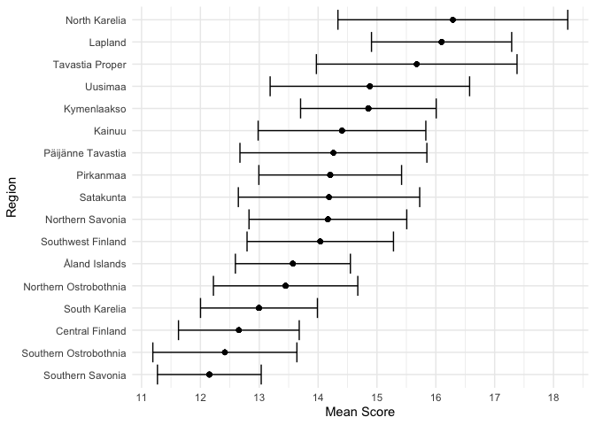

```r
df %>% ggplot(aes(mean_score, region)) +
  geom_point() + # All mean scores of each region at the same coordinates, geom_jitter would reveal this
  stat_summary(aes(score), fun.data = mean_se, geom="errorbar") + # Errorbars from scores
  theme_minimal() +
  scale_x_continuous(name = "Mean Score", breaks=c(10:20)) +
  scale_y_discrete(name = "Region")
```

# Week 4

## Exercise 1

Read the region_scores.csv data (make sure you have the data file in the right folder).

Create a figure that shows the distributions (density plots or histograms) of **age** and **score** in separate subplots (facets). What do you need to do first?

In the figure, set individual x-axis limits for age and score by modifying the `scales` parameter within `facet_wrap()`.

**Hint**: To make things simpler, you can begin by selecting only the variables you need here, i.e. age and score.

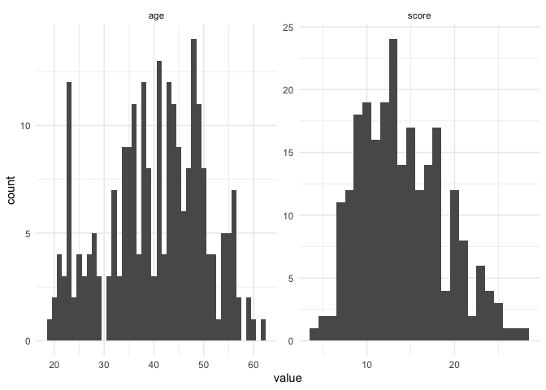

```r
df %>% gather(key = "key", value = value, 5:6) %>% ggplot(aes(x=value)) +
  geom_histogram(binwidth = 1) +
  facet_wrap("key", scales = "free") +
  theme_minimal()
```

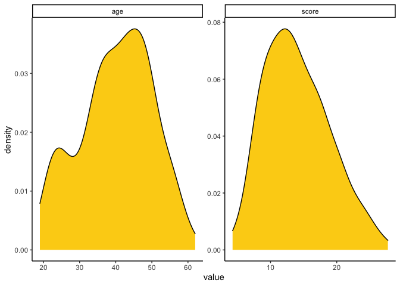

```r
df %>% gather(key = "key", value = value, 5:6) %>% ggplot(aes(x=value)) +
  geom_density(fill="#fcd116") +
  facet_wrap("key", scales = "free") +
  theme_classic()
```

## Exercise 2

In this exercise, you will use the built-in iris dataset.

```r
head(iris)
```

```
##   Sepal.Length Sepal.Width Petal.Length Petal.Width Species
## 1          5.1         3.5          1.4         0.2  setosa
## 2          4.9         3.0          1.4         0.2  setosa
## 3          4.7         3.2          1.3         0.2  setosa
## 4          4.6         3.1          1.5         0.2  setosa
## 5          5.0         3.6          1.4         0.2  setosa
## 6          5.4         3.9          1.7         0.4  setosa
```

### 2.1

Make the data into long format: gather all variables except species into new variables **var** (variable names) and **measure** (numerical values). You should end up with 600 rows and 3 columns (Species, var, and measure). Assign the result into `iris_long`.

```r
iris_long <- iris %>% gather(key = "var", value = measure, -Species)
```

### 2.2

In `iris_long`, separate **var** into two variables: **part** (Sepal/Petal values) and **dim** (Length/Width).

Then, spread the measurement values to new columns that get their names from **dim**. You must create row numbers by dim group before doing this.

You should now have 300 rows of variables Species, part, Length and Width (and row numbers). Assign the result into `iris_wide`.

```r
iris_wide <- iris_long %>% separate(var, c("part", "dim")) %>% group_by(dim) %>% mutate(row_no = row_number()) %>% spread(dim, measure)
```

### 2.3

Using `iris_wide`, plot a scatter plot of length on the x-axis and width on the y-axis. Colour the points by part.

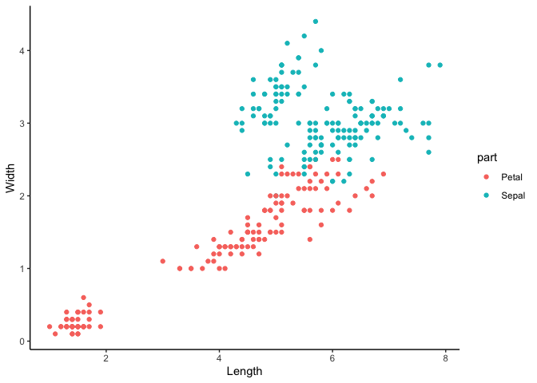

```r
iris_wide %>% ggplot(aes(x = Length, y = Width, color = part)) +
  geom_point() +
  theme_classic()
```

## Working with your own data

In exercises 3-5, you’ll work with your own dataset. **If you don’t have you own data, use the fss_learning.csv data (see description below).**

In these exercises, you are required to provide an overview of your data, using the tools we have learned so far. Because all datasets are different, the format of the exercises is quite open. You will get points for being thorough and trying your best - even if you didn’t know how to write something in code, be explicit with what you were **trying** to achieve. When submitting the exercises, **please return both an .Rmd and an .html file! The HTML file created by previewing a Notebook (with the suffix .nb.html) is fine, but make sure that the HTML contains all the code and output that is needed for getting an impression of the data. In other words, the document needs to be readable without having access to the full dataset.**

### the fss_learning data

fss_learning.csv contains data from a longitudinal skill learning experiment. There are observations at multiple levels: a total of 18 **participants**, each completing 8 **sessions** which consist of 5 **runs** (trials) of a game-like driving task (i.e. 8*5 = 40 trials per participant). You can read more about the design [here](https://doi.org/10.3389/fpsyg.2019.01126).

In the data, there are trial-level measures related to performance (number of **collisions**, **duration** in seconds, **distance** travelled), as well as self-reports on a scale of 1-7 (variables fluency:comp3) collected after each trial or session.

## Exercise 3

As I don’t have suitable data for these exercises I’ll do the ex 3 and ex 4 with the fss_learning data. Additionally, in ex 5 I describe my network data I have now and will have in the future. I also make some network visualizations with example data.

### 3.1

Importing fss data into R.

### 3.2

Print the structure/glimpse/summary of the data. Outline briefly what kind of variables you have and if there are any missing or abnormal values. Make sure that each variable has the right class (numeric/character/factor etc).

```r
structure(fss)
```

```
## # A tibble: 720 × 17
##    participant gender session   run collisions duration distance cumrun fluency
##          <dbl> <chr>    <dbl> <dbl>      <dbl>    <dbl>    <dbl>  <dbl>   <dbl>
##  1           1 male         1     1         26     234.   24197.      1    4.75
##  2           1 male         1     2         30     205.   24197.      2    4.5
##  3           1 male         1     3         20     190.   24199.      3    5.25
##  4           1 male         1     4         13     181.   24198.      4    5
##  5           1 male         1     5         18     189.   24198.      5    4.25
##  6           1 male         2     1         18     185.   24198.      6    4
##  7           1 male         2     2         21     173.   24196.      7    5.5
##  8           1 male         2     3         20     187.   24197.      8    4
##  9           1 male         2     4         15     174.   24198.      9    5
## 10           1 male         2     5         15     197.   24199.     10    3.75
## # … with 710 more rows, and 8 more variables: absorption <dbl>, flow <dbl>,
## #   pi1 <dbl>, pi2 <dbl>, pi3 <dbl>, comp1 <dbl>, comp2 <dbl>, comp3 <dbl>
```

```r
glimpse(fss)
```

```
## Rows: 720
## Columns: 17
## $ participant <dbl> 1, 1, 1, 1, 1, 1, 1, 1, 1, 1, 1, 1, 1, 1, 1, 1, 1, 1, 1, 1…
## $ gender      <chr> "male", "male", "male", "male", "male", "male", "male", "m…
## $ session     <dbl> 1, 1, 1, 1, 1, 2, 2, 2, 2, 2, 3, 3, 3, 3, 3, 4, 4, 4, 4, 4…
## $ run         <dbl> 1, 2, 3, 4, 5, 1, 2, 3, 4, 5, 1, 2, 3, 4, 5, 1, 2, 3, 4, 5…
## $ collisions  <dbl> 26, 30, 20, 13, 18, 18, 21, 20, 15, 15, 21, 17, 8, 18, 13,…
## $ duration    <dbl> 233.6105, 204.8506, 190.1887, 181.4123, 188.9267, 184.5798…
## $ distance    <dbl> 24196.57, 24197.47, 24199.04, 24197.93, 24197.89, 24197.58…
## $ cumrun      <dbl> 1, 2, 3, 4, 5, 6, 7, 8, 9, 10, 11, 12, 13, 14, 15, 16, 17,…
## $ fluency     <dbl> 4.75, 4.50, 5.25, 5.00, 4.25, 4.00, 5.50, 4.00, 5.00, 3.75…
## $ absorption  <dbl> 6.0, 4.6, 5.4, 5.0, 4.6, 4.8, 5.6, 5.0, 5.8, 4.2, 4.6, 5.2…
## $ flow        <dbl> 5.444444, 4.555556, 5.333333, 5.000000, 4.444444, 4.444444…
## $ pi1         <dbl> 5, 3, 5, 4, 4, 3, 4, 4, 5, 3, 4, 4, 5, 4, 3, 4, 4, 4, 5, 4…
## $ pi2         <dbl> 2, 2, 3, 3, 3, 3, 4, 3, 3, 3, 3, 4, 4, 3, 4, 3, 3, 4, 5, 4…
## $ pi3         <dbl> 3, 2, 2, 2, 2, 3, 3, 3, 2, 3, 3, 4, 3, 3, 3, 3, 4, 4, 4, 3…
## $ comp1       <dbl> NA, NA, NA, NA, 3, NA, NA, NA, NA, 3, NA, NA, NA, NA, 3, N…
## $ comp2       <dbl> NA, NA, NA, NA, 5, NA, NA, NA, NA, 5, NA, NA, NA, NA, 5, N…
## $ comp3       <dbl> NA, NA, NA, NA, 4, NA, NA, NA, NA, 4, NA, NA, NA, NA, 4, N…
```

```r
summary(fss)
```

```
##   participant      gender             session          run      collisions
##  Min.   : 1.0   Length:720         Min.   :1.00   Min.   :1   Min.   : 4.00
##  1st Qu.: 5.0   Class :character   1st Qu.:2.75   1st Qu.:2   1st Qu.:13.00
##  Median : 9.5   Mode  :character   Median :4.50   Median :3   Median :17.00
##  Mean   : 9.5                      Mean   :4.50   Mean   :3   Mean   :17.67
##  3rd Qu.:14.0                      3rd Qu.:6.25   3rd Qu.:4   3rd Qu.:22.00
##  Max.   :18.0                      Max.   :8.00   Max.   :5   Max.   :43.00
##                                                               NA's   :1
##     duration        distance         cumrun         fluency
##  Min.   :160.0   Min.   :24196   Min.   : 1.00   Min.   :2.000
##  1st Qu.:172.5   1st Qu.:24197   1st Qu.:10.50   1st Qu.:4.000
##  Median :181.3   Median :24198   Median :20.00   Median :4.750
##  Mean   :186.3   Mean   :24198   Mean   :20.47   Mean   :4.617
##  3rd Qu.:194.7   3rd Qu.:24198   3rd Qu.:30.00   3rd Qu.:5.250
##  Max.   :413.3   Max.   :24200   Max.   :40.00   Max.   :7.000
##  NA's   :1       NA's   :1       NA's   :1       NA's   :1
##    absorption         flow            pi1             pi2
##  Min.   :2.400   Min.   :2.444   Min.   :1.000   Min.   :1.000
##  1st Qu.:4.700   1st Qu.:4.444   1st Qu.:5.000   1st Qu.:2.000
##  Median :5.200   Median :5.000   Median :6.000   Median :4.000
##  Mean   :5.248   Mean   :4.968   Mean   :5.328   Mean   :3.702
##  3rd Qu.:5.800   3rd Qu.:5.556   3rd Qu.:6.000   3rd Qu.:5.000
##  Max.   :7.000   Max.   :7.000   Max.   :7.000   Max.   :7.000
##  NA's   :1       NA's   :1       NA's   :1       NA's   :1
##       pi3            comp1           comp2           comp3
##  Min.   :1.000   Min.   :1.000   Min.   :2.000   Min.   :2.000
##  1st Qu.:1.000   1st Qu.:3.000   1st Qu.:4.000   1st Qu.:4.000
##  Median :2.000   Median :3.000   Median :4.000   Median :4.000
##  Mean   :2.713   Mean   :3.514   Mean   :4.264   Mean   :3.993
##  3rd Qu.:4.000   3rd Qu.:5.000   3rd Qu.:5.000   3rd Qu.:4.000
##  Max.   :7.000   Max.   :6.000   Max.   :6.000   Max.   :6.000
##  NA's   :1       NA's   :576     NA's   :576     NA's   :576
```

```r
fss <- fss %>% mutate(gender = as.factor(gender),
                      participant = as.integer(participant),
                      session = as.integer(session),
                      run = as.integer(run),
                      cumrun = as.integer(cumrun))

head(fss)
```

```
## # A tibble: 6 × 17
##   participant gender session   run collisions duration distance cumrun fluency
##         <int> <fct>    <int> <int>      <dbl>    <dbl>    <dbl>  <int>   <dbl>
## 1           1 male         1     1         26     234.   24197.      1    4.75
## 2           1 male         1     2         30     205.   24197.      2    4.5
## 3           1 male         1     3         20     190.   24199.      3    5.25
## 4           1 male         1     4         13     181.   24198.      4    5
## 5           1 male         1     5         18     189.   24198.      5    4.25
## 6           1 male         2     1         18     185.   24198.      6    4
## # … with 8 more variables: absorption <dbl>, flow <dbl>, pi1 <dbl>, pi2 <dbl>,
## #   pi3 <dbl>, comp1 <dbl>, comp2 <dbl>, comp3 <dbl>
```

## Exercise 4

Pick a few (2-5) variables of interest from your data (ideally, both categorical and numerical).

For **categorical variables**, count the observations in each category (or combination of categories). Are the frequencies balanced?

Only categorical variable variable count that I’m intrested is gender.

```r
fss %>% count(gender)
```

```
## # A tibble: 2 × 2
##   gender     n
##   <fct>  <int>
## 1 female   320
## 2 male     400
```

I this this is ok, even if it is not quite equal.

For **numerical variables**, compute some summary statistics (e.g. min, max, mean, median, SD) over the whole dataset or for subgroups. What can you say about the distributions of these variables, or possible group-wise differences?

```r
fss_means <- fss %>% group_by(participant, session) %>% summarise(flow_mean = mean(flow, na.rm = TRUE), flow_sd = sd(flow, na.rm = TRUE), collisions_mean = mean(collisions, na.rm = TRUE), speed = mean(distance/duration)) # participant 8 has some NA values, using na.rm = TRUE functions no to drop those NA values before computung the summary statistic. Otherwise the result would also be just NA
head(fss_means)
```

```
## # A tibble: 6 × 6
## # Groups:   participant [1]
##   participant session flow_mean flow_sd collisions_mean speed
##         <int>   <int>     <dbl>   <dbl>           <dbl> <dbl>
## 1           1       1      4.96   0.449            21.4  122.
## 2           1       2      4.8    0.673            17.8  132.
## 3           1       3      5.09   0.480            15.4  136.
## 4           1       4      4.84   0.435            14.2  139.
## 5           1       5      5.22   0.716            12    140.
## 6           1       6      5.67   0.283             8.4  148.
```

Let’s try to make a bubble plot.

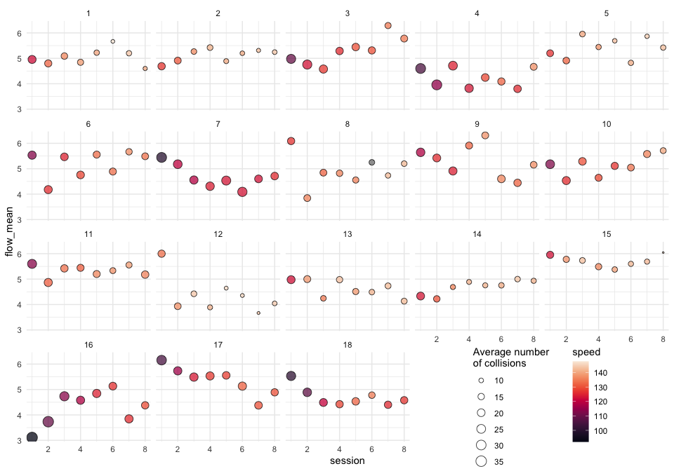

```r
fss_means %>% ggplot(aes(x = session, y = flow_mean, size = collisions_mean, fill = speed)) +
  geom_point(alpha = 0.75, shape=21, color = "black") +
  scale_size(range = c(0.5, 5), name="Average number \nof collisions") +
  scale_fill_viridis(option="F") +
  facet_wrap("participant") +
  theme_minimal() +
  theme(legend.position = c(0.8, 0.08), legend.box = 'horizontal')
```

Even tough it is possible to include lot of information into a bubble plot, I don’t think it is that useful or good. At least not here with the 18 facets. In some limited cases it might be applicable with a single facet if all the variables are meaningfully connected.

## Exercise 5

The network data I have is used in article I have submitted, but I do not want make the data set public just yet (everything I do in this course is on my GitHub on a public repository). But I describe the data and use social network data from a movie for learning igraph package and network visualizations.

### 5.1

Describe if there’s anything else you think should be done as “pre-processing” steps (e.g. recoding/grouping values, renaming variables, removing variables or mutating new ones, reshaping the data to long format, merging data frames together).

The network data I have in my own research is already in nice format. Actually, for the next analyses I will still use Python as I have the network data as graph-tool objects and I have all useful functions already written. However, if need be the network data is easily tranferred as link-list in dataframes between python and R.

In another project I might need to analyze concept maps as networks. I get the concept map data as json-files and I need to write simple function to convert the data into a igraph object. This should be straightforward with the jsonlite library.

### 5.2

Do you have an idea of what kind of relationships in your data you would like to visualise and for which variables? For example, would you like to depict variable distributions, the structure of multilevel data, summary statistics (e.g. means), or include model fits or predictions?

Depending which network I’m analyzing I need to compute different centrality measures. Those measures are then used in the network visualizations. In my own research I need to compute correlations between different network measures and also, maybe, centrality distributions. With the **ggpairs** these are visualized nicely.

## Network Visualizations with igraph

This is my own exercise to learn igraph package and to visualize (and analyze) networks.

I selected one of my favorite movies, *Big Lebowski* to experiment with. First, load the data as network and print all nodes.

```r
g <- movie_103 # network g of the Big Lebowski
V(g) # all nodes
```

```
## + 37/37 vertices, named, from fb41dcd:
##  [1] ALLAN        BARTENDER    BLOND MAN    BRANDT       BUNNY
##  [6] CHIEF        CHINESE MAN  DA FINO      DIETER       DONNELLY
## [11] DONNY        DRIVER       DUDE         FIRST MAN    FRANZ
## [16] GARY         HALLWAY      KIEFFER      MAN          MAUDE
## [21] OLDER COP    PILAR        POLICEMAN    QUINTANA     SECOND MAN
## [26] SMOKEY       THE STRANGER THIRD MAN    TONY         TREEHORN
## [31] WAITRESS     WALTER       WOMAN        WOO          YOUNG MAN
## [36] YOUNG WOMAN  YOUNGER COP
```

Let’s make two simple plots with different layouts and settings

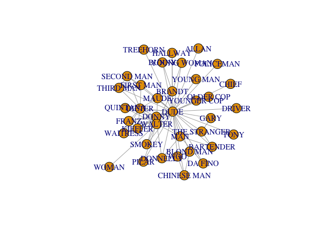

```r
plot(g
     )
```

Let’s make it bigger with circular layout and nicer colors.

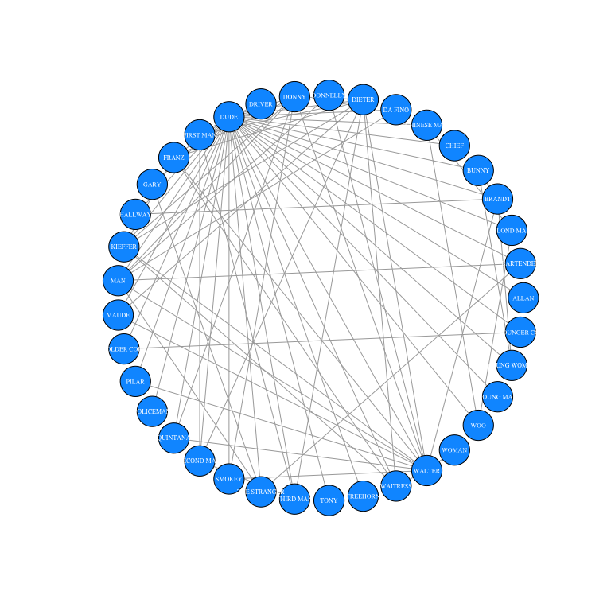

```r
plot(g,
     layout = layout.circle(g),
     vertex.size=15,
    vertex.color="#009bff",
    vertex.label.cex=0.5,
    vertex.label.color="white",
    vertex.frame.color="black")
```

Let’s now calculate network measures and use those for nicer plots.

```r
# degree_centrality
df <- base::as.data.frame(degree(g))
colnames(df) <- c("deg")
# eigen_centrality
df$eig <- eigen_centrality(g)$vector
# page_rank
df$pr <-  page_rank(g)$vector
# Katz_degree
# There's no function to calculate katz-centrality. Need to make my own, if I plan to use R for my analyses.
df <- df %>% mutate(deg = as.integer(deg))
head(df)
```

```
##           deg        eig         pr
## ALLAN       1 0.02940050 0.00659938
## BARTENDER   3 0.03617716 0.01260112
## BLOND MAN   3 0.06158241 0.01651148
## BRANDT      5 0.32386711 0.04300233
## BUNNY       3 0.04010136 0.01285149
## CHIEF       1 0.02940050 0.00659938
```

Also ggpairs-plot for the measures. All correlate nicely, as they should!

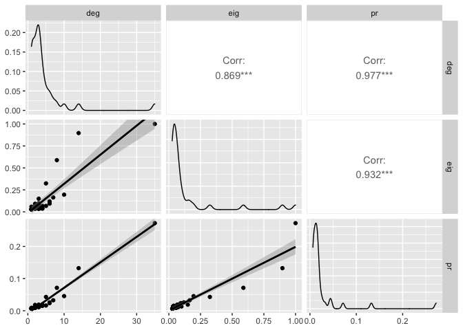

```r
df %>% ggpairs(lower = list(continuous = "smooth"))
```

Plot with *Kamada & Kawai* layout and node size from node degree.

[figure not shown]

```r
plot(g,
     layout = layout.kamada.kawai(g),
     vertex.size=df$deg,
     vertex.color="#009bff",
     vertex.label.cex=0.7,
     vertex.label.color="black",
     vertex.frame.color="black")
```

Star plot with the *Dude* rightfully in the center and using eigencentrality to set the order and size of the nodes. It would be nicer to be able to set the starting point for the circular layout so that *Walter* would on top. I did not find a simple or easy way to do this.

[figure not shown]

```r
plot(g,
     layout = layout.star(g, center = V(g)["DUDE"], order = order(df$eig, decreasing = TRUE)),
     vertex.size=df$eig*20,
     vertex.color="#009bff",
     vertex.label.cex=0.7,
     vertex.label.color="black",
     vertex.frame.color="black")
```

# Week 5 Exercises"

```r
library(tidyr)
library(ggplot2)
library(tidyverse)
library(lubridate)
```

Read the file timeuse_tidy.rds with `readRDS()`. The file contains the dataset that we tidied in the exercise session: records of daily time use from participants over multiple days. Note that since the data has been stored as rds (R-specific format), column types and factor levels are as we left them, and don’t need to be re-corrected.

```r
tidytime <- readRDS("timeuse_tidy.rds")
glimpse(tidytime)
```

```
## Rows: 26,568
## Columns: 9
## $ indivID        <chr> "1013302", "1013302", "1013302", "1013302", "1013302", …
## $ date           <date> 2016-11-11, 2016-11-11, 2016-11-11, 2016-11-11, 2016-1…
## $ female         <fct> 0, 0, 0, 0, 0, 0, 0, 0, 0, 0, 0, 0, 0, 0, 0, 0, 0, 0, 0…
## $ age            <dbl> 70, 70, 70, 70, 70, 70, 70, 70, 70, 70, 70, 70, 70, 70,…
## $ occ_full_time  <fct> 0, 0, 0, 0, 0, 0, 0, 0, 0, 0, 0, 0, 0, 0, 0, 0, 0, 0, 0…
## $ activity_class <fct> Lifts, Work, Education, Shopping, Business, Petrol, Soc…
## $ time_spent     <dbl> 0, 0, 0, 0, 0, 0, 0, 0, 6, 1424, 10, 0, 0, 0, 0, 0, 0, …
## $ weekday        <ord> Fri, Fri, Fri, Fri, Fri, Fri, Fri, Fri, Fri, Fri, Fri, …
## $ week_number    <dbl> 46, 46, 46, 46, 46, 46, 46, 46, 46, 46, 46, 46, 46, 46,…
```

## Exercise 1

### 1.1

Create a new variable that contains combined activity classes: “Work or school” (Work, Business, Education), “Free time” (Shopping, Social / Leisure, Home, Vacation), and “Other”.

```r
act_key <- c("Work" = "Work or school", "Business" = "Work or school", "Education" = "Work or school", "Shopping" = "Free time", "Social / Leisure" = "Free time", "Home" = "Free time", "Vacation" = "Free time")

tidytime <- tidytime %>% mutate(activity_class = recode(activity_class, !!!act_key, .default = "Other") %>% factor)
```

Calculate the mean time spent on each of the combined activity classes, grouped by **weekday, participant ID, and occ_full_time**.

```r
mean_times <- tidytime %>% group_by(weekday, indivID, occ_full_time, activity_class) %>% summarise(mean(time_spent))
head(mean_times)
```

```
## # A tibble: 6 × 5
## # Groups:   weekday, indivID, occ_full_time [2]
##   weekday indivID occ_full_time activity_class `mean(time_spent)`
##   <ord>   <chr>   <fct>         <fct>                       <dbl>
## 1 Mon     1013302 0             Work or school                0
## 2 Mon     1013302 0             Other                         3.6
## 3 Mon     1013302 0             Free time                   356.
## 4 Mon     1056237 1             Work or school                0
## 5 Mon     1056237 1             Other                         0
## 6 Mon     1056237 1             Free time                   360
```

### 1.2

Visualise the means you calculated.

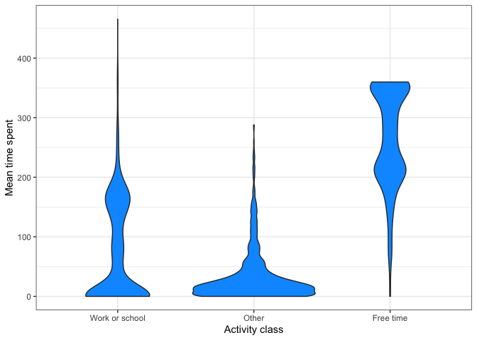

```r
mean_times %>% ggplot(aes(x = activity_class, y = `mean(time_spent)`)) +
  geom_violin(fill="#009bff") + # HY blue
  theme_bw() +
  scale_y_continuous(name = "Mean time spent") +
  scale_x_discrete(name = "Activity class")
```

## Exercise 2

### 2.1

What is computed in the code chunk below - what do the numbers tell you?

Can you think of another way to calculate the same thing?

```r
date_counts <- tidytime %>%
  distinct(indivID, date) %>% # Select distinct individuals and dates
  arrange(date) %>%           # Arrange the data by date
  count(date)                 # Count individuals per each date

date_counts                   # Show counts
```

```
## # A tibble: 73 × 2
##    date           n
##    <date>     <int>
##  1 2016-10-14     6
##  2 2016-10-15    11
##  3 2016-10-16    10
##  4 2016-10-17    10
##  5 2016-10-18    14
##  6 2016-10-19    16
##  7 2016-10-20    11
##  8 2016-10-21    11
##  9 2016-10-22    17
## 10 2016-10-23    18
## # … with 63 more rows
```

### 2.2

Plot the numbers from above (use points, lines, or whatever you think is suitable).

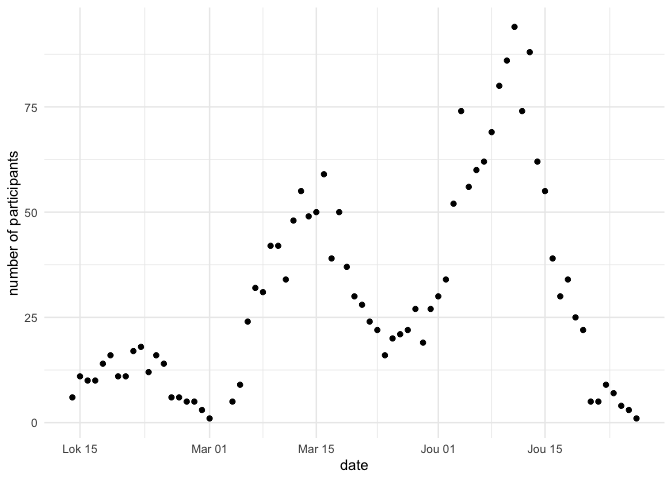

```r
date_counts %>% ggplot(aes(x = date, y = n)) +
  geom_point() +
  theme_minimal() +
  scale_y_continuous(name = "number of participants")
```

## Exercise 3

### 3.1

Count the **total number of participants** in the data.

```r
tidytime %>% distinct(indivID) %>% count()
```

```
## # A tibble: 1 × 1
##       n
##   <int>
## 1   356
```

### 3.2

For each participant, count the **number of separate days** that they recorded their time use on.

```r
tidytime %>% group_by(indivID) %>% distinct(date) %>% count(indivID)
```

```
## # A tibble: 356 × 2
## # Groups:   indivID [356]
##    indivID     n
##    <chr>   <int>
##  1 1013302    10
##  2 1056237     7
##  3 1103940     7
##  4 118068      7
##  5 1198262     5
##  6 1202035     5
##  7 121881      7
##  8 1226238     1
##  9 1292043     4
## 10 1326897     4
## # … with 346 more rows
```

## Exercise 4

Explain step by step what happens in the code chunk below and what the final figure represents.

*Explanations as comments. The final figure represents when the participants recorded their activities (points) with the overall all timespan (lines). The individuals are order by start date top to bottom and thus the figure shows this general trend left-to-right and top-to-bottom. Colors represent start month.*

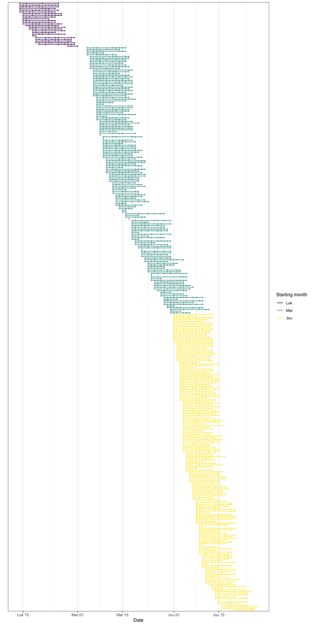

```r
tidytime %>%
  group_by(indivID) %>% # Group by individuals
  mutate(start_date = min(date)) %>% # Compute and add start date as minimum date per each individual (as it is grouped)
  ungroup %>% # ungroup the data
  mutate(indivID = factor(indivID), # factorize indivID variable
         indivID = fct_reorder(indivID, start_date) %>% fct_rev()) %>% # reorder indivID by start date
  ggplot(aes(date, indivID, colour = month(start_date, label = T))) + # init plot with date in x-axis and individuals on y-axis, color data by starting month that are displayed as a character strings
  geom_line() + # add line plot
  geom_point(size=.5, alpha=.1) + # add points and set point size and transparency (alpha channel for points' colors)
  theme_bw() + # set the bw-theme (dark-on-light)
  scale_y_discrete(breaks = "none") + # remove ticks form y-axis
  labs(x = "Date", y = "", colour = "Starting month") # set labels for the axes and
```

## Extra - categorical time and value

I got intrested about Ben’s example of restaurant menus as categorical time and value. And of course how to visualize those. Luckily, one restaurant/chef in Lohja, [Mikko Utter](http://www.mikkoutter.fi/kaudet.html), has menus for each season available at his webpage. So I crabbed those and coded the menu items very rough to food groups for simple visualizations. Unfortunately, the seasons are in Finnish and I do not know good translations for all so I did not translate those.

```r
library(cowplot) #for side-by-side plots
```

Read the data `utter.csv´ and mutate to categories. Ids from row numbers that are then used to reorder the seasons so that they remain in temporal order.

```r
utter <- read_csv2("utter.csv", col_types = cols())

utter <- utter %>% mutate(
  season = as.factor(season),
  group = as.factor(group),
  id = as.numeric(row.names(utter))
)

utter <- utter %>% mutate(
  season = fct_reorder(season, id)
)

head(utter)
```

```
## # A tibble: 6 × 4
##   season `menu item` group        id
##   <fct>  <chr>       <fct>     <dbl>
## 1 Napa   Porkkana    Vegetable     1
## 2 Napa   Mustajuuri  Vegetable     2
## 3 Napa   Kuivaliha   Meat          3
## 4 Napa   Cheddar     Cheese        4
## 5 Napa   Hirvi       Meat          5
## 6 Napa   Päärynä     Fruit         6
```

Simple bar plot and pie plot side-by-side. The pie plot is, according to the *Grammar of Graphics*, just a bar plot with polar coordinates. Thus making pie plot from bar plot with the ggplot is straightforward.

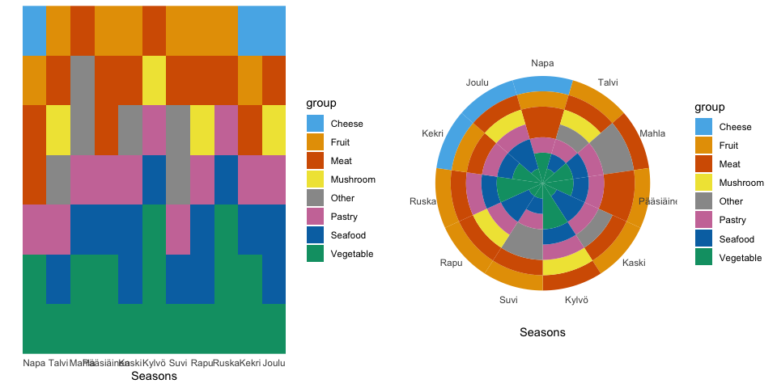

```r
#Custom palette for nicer colors. Original from http://www.cookbook-r.com/Graphs/Colors_(ggplot2)/ but this is reordered to correspond bit nicer with the food groups
myPalette <- c("#56B4E9", "#E69F00", "#D55E00", "#F0E442", "#999999", "#CC79A7", "#0072B2", "#009E73")

p1 <- utter %>% ggplot(aes(x = season, fill = group)) + # Keep the order same as in the df
  geom_bar(width = 1) +
  scale_fill_manual(values=myPalette) +
  scale_y_discrete(breaks = NULL, expand = c(0, 0)) +
  labs(x="Seasons", y="") +
  theme_minimal() +
  theme(panel.grid = element_line(color = "white"))

# Wrap bars into a pie
start_angle = -0.5*(360/11)*(pi/180) # fixing start angle so that the first season "napa" is at the top
p2 <- p1 +coord_polar(start = start_angle)

plot_grid(p1, p2)
```

Usually pie plots are not recomended, but I like to visualize a year as circle so to me atleast the pie plot is more intuitive and pleasing. Also, this video [Nightingale Diagrams - Numberphile](https://www.youtube.com/watch?v=VTdVPNvwULM) discusses and shows nice circular visualizations

Here is a horizontal bar plot of number of each food groups colored by the seasons. This uses the default color map of ggplot2 is quite horrendous, but then again I don’t think this is a good visualization of this data.

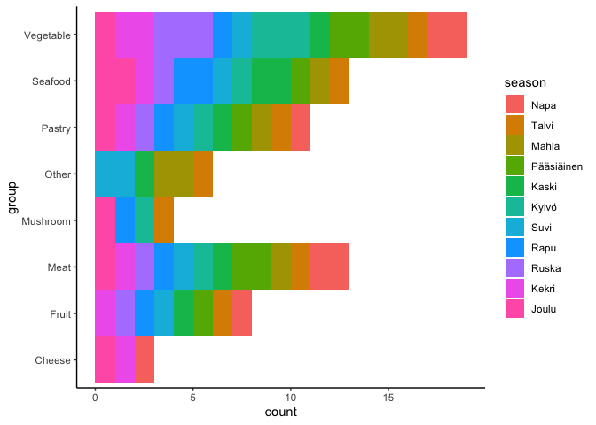

```r
utter %>% ggplot(aes(y = group, fill = season)) +
  geom_bar(stat = "count", width = 1) +
  theme_classic()
```

Finally, let’s make a pie plots of the grousp for each season. Again, I think here the pie plots are visually pleasing.

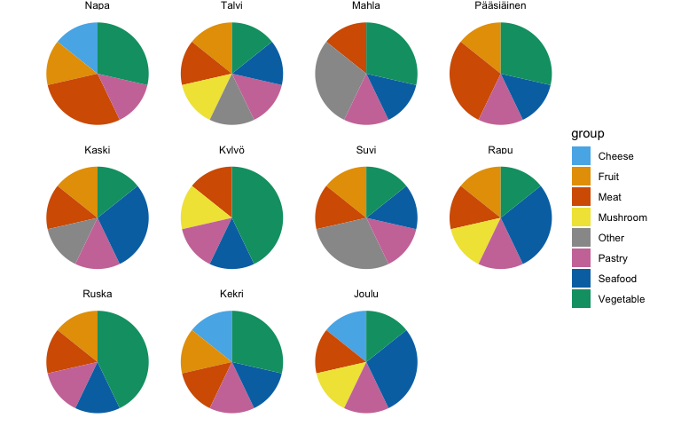

```r
utter %>% group_by(season) %>% count(group) %>%  ggplot(aes(x = "", y = n, fill = group)) +
  geom_bar(stat = "identity", width = 1) +
  coord_polar("y", start = 0) +
  scale_y_continuous(breaks = NULL) +
  facet_wrap(~season) +
  scale_fill_manual(values=myPalette) +
  labs(x="", y="") +
  theme_void()
```

# Week 6

```r
library(ggplot2)
library(tidyverse)
```

## Exercise 1

The data frames df_w and df_f represent repeated measures data from 60 participants. Variables F1-F3 and W1-W3 are “sub-variables” that will be used to make two composite variables F_total and W_total, respectively.

### 1.1

Merge the two data frames together.

```r
df <- full_join(df_w, mutate(df_f, session = as.factor(session)))
head(df)
```

```
##   id session group W1 W2 W3 F1 F2 F3
## 1  1       1     1  2  3  2  3  0  0
## 2  1       2     1  1  0  0  0  0  3
## 3  2       1     1  0  2  1  0  0  0
## 4  2       2     1  3  2  0  2  0  2
## 5  3       1     1  3  2  0  0  0  0
## 6  3       2     1  0  3  3  1  0  0
```

### 1.2

Using the merged data frame, create the **composite variables F_total and W_total, which are the sums of F1-F3 and W1-W3, respectively** (i.e. their values can range from 0 to 9).

```r
df <- df %>% mutate(F_total = F1+F2+F3, W_total = W1+W2+W3)
head(df)
```

```
##   id session group W1 W2 W3 F1 F2 F3 F_total W_total
## 1  1       1     1  2  3  2  3  0  0       3       7
## 2  1       2     1  1  0  0  0  0  3       3       1
## 3  2       1     1  0  2  1  0  0  0       0       3
## 4  2       2     1  3  2  0  2  0  2       4       5
## 5  3       1     1  3  2  0  0  0  0       0       5
## 6  3       2     1  0  3  3  1  0  0       1       6
```

## Exercise 2

### 2.1

Visualise the distributions of F_total and W_total for the two groups and measurement sessions (for example as boxplots).

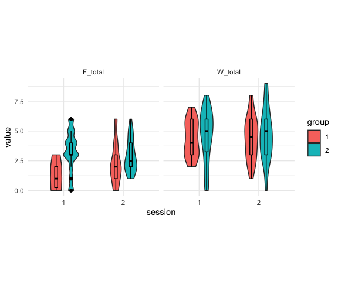

```r
df %>% gather(key = "key", value = value, 10:11) %>%
  ggplot(aes(x=session, y = value, fill = group)) +
  geom_violin(width = 0.5)+
  geom_boxplot(width=0.1, color="black", show.legend = FALSE, position = position_dodge(width = 0.5)) +
  facet_wrap(~key) +
  theme_minimal() +
  coord_fixed(1/5)
```

It is quite nice to combine the violin and box plots. This gives good overall picture of the distribution of the data. As the data was simulated, it is not clear should we compare groups or sessions i.e. which values should be used for ‘x’ and ‘fill’. Luckily, it would be trivial to change those.

This also got me thinking is there a way to use patterns instead of colors for the fill. Main reason is that even nowadays some journals do not accept color pictures. So let’s flip ‘x’ and ‘fill’ and try to use patterns.

Apparently, ‘ggpattern’ package is needed, so let’s first install and import that.

```r
#remotes::install_github("coolbutuseless/ggpattern")
library(ggpattern)
```

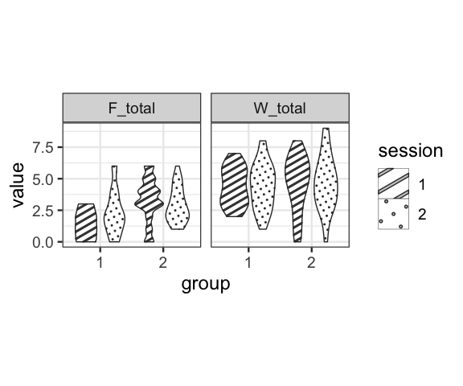

```r
df %>% gather(key = "key", value = value, 10:11) %>%
  ggplot(aes(x=group, y = value)) +
  geom_violin_pattern(aes(pattern = session)) +
  facet_wrap(~key) +
  theme_bw(18) +
  theme(legend.key.size = unit(1, "cm")) +
  coord_fixed(1/5)
```

Maybe not as nice as with the colors, but clear enough and usable. Also, I did not include box plot as the boxes would clas with the violin patterns.

### 2.2

Fit a linear regression model with F_total as the DV, and session and group as predictors.

```r
fit <- lm(F_total ~ session+group, data = df)
summary(fit)
```

```
##
## Call:
## lm(formula = F_total ~ session + group, data = df)
##
## Residuals:
##     Min      1Q  Median      3Q     Max
## -2.9667 -1.2000  0.0333  1.0333  4.0333
##
## Coefficients:
##             Estimate Std. Error t value Pr(>|t|)
## (Intercept)   1.7333     0.2422   7.156 7.84e-11 ***
## session2      0.2333     0.2797   0.834    0.406
## group2        1.2333     0.2797   4.409 2.31e-05 ***
## ---
## Signif. codes:  0 '***' 0.001 '**' 0.01 '*' 0.05 '.' 0.1 ' ' 1
##
## Residual standard error: 1.532 on 117 degrees of freedom
## Multiple R-squared:  0.1469, Adjusted R-squared:  0.1323
## F-statistic: 10.07 on 2 and 117 DF,  p-value: 9.224e-05
```

### 2.3

Look at the means of F_total by group and session. How are they linked to the linear regression model coefficients?

First compute the means.

```r
gm <- df %>% group_by(group) %>% summarise(meanF = mean(F_total))
gm
```

```
## # A tibble: 2 × 2
##   group meanF
##   <fct> <dbl>
## 1 1      1.85
## 2 2      3.08
```

```r
sm <- df %>% group_by(session) %>% summarise(meanF = mean(F_total))
sm
```

```
## # A tibble: 2 × 2
##   session meanF
##   <fct>   <dbl>
## 1 1        2.35
## 2 2        2.58
```

Looks like the difference between means are close to the coefficients of the fit. Let’s check that.

```r
cat("Diffrenece between group means: ", as.double(gm[2,2] - gm[1,2]),
    "\nDiffrenece between session means: ", as.double(sm[2,2] - sm[1,2]))
```

```
## Diffrenece between group means:  1.233333
## Diffrenece between session means:  0.2333333
```

Yep!

## Exercise 3

Visualise the [anscombe dataset](https://rdrr.io/r/datasets/anscombe.html) using ggplot2.

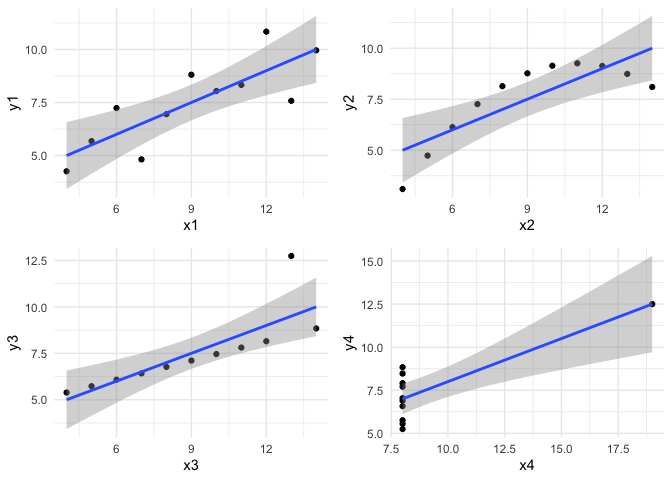

```r
library(cowplot)

p1 <- anscombe %>% ggplot(aes(x1, y1)) + geom_point() + geom_smooth(method="lm") + theme_minimal()
p2 <- anscombe %>% ggplot(aes(x2, y2)) + geom_point() + geom_smooth(method="lm") + theme_minimal()
p3 <- anscombe %>% ggplot(aes(x3, y3)) + geom_point() + geom_smooth(method="lm") + theme_minimal()
p4 <- anscombe %>% ggplot(aes(x4, y4)) + geom_point() + geom_smooth(method="lm") + theme_minimal()

plot_grid(p1, p2, p3, p4)
```

## Exercise 4

Not sure if I’ll do this as I do not have suitable data for the final assignment. I might do something with concept maps and networks as I might to do that as part of one project. In any case, below is the alternative final assignment.

# Alternative Final Assignment

Alternative final assignment was to reproduce the following picture:

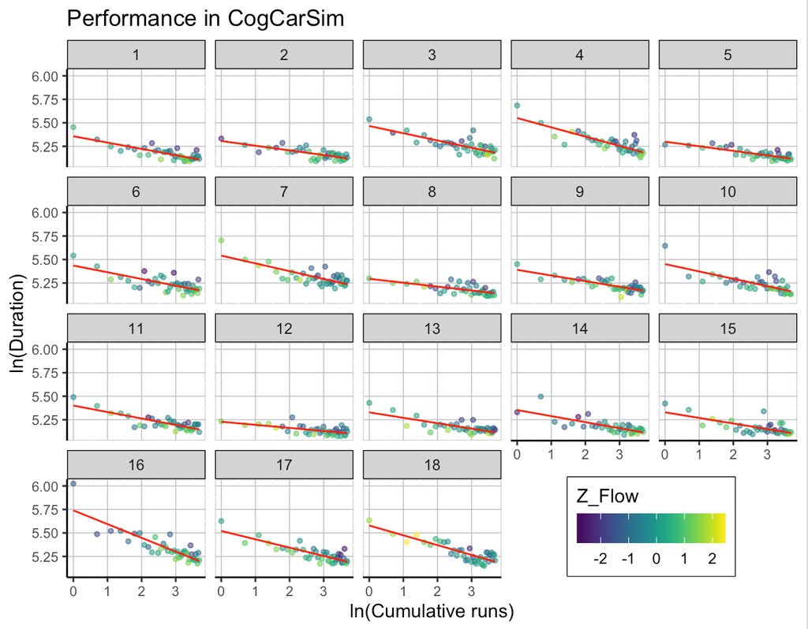

There are some additional instruction, but I thought it might be fun to try to reproduce this first without them. Clearly, facets are for the participants, plots are scatter plots with runs on the x-axis and duration of each run on y-axis, the points are colored with (normalized?) flow values using viridis palette and there is red trend line without the confidence band. Theme is probably the bw and there is custom placement for the legend that also has border. I do not remember if the legend border is part of theme_bw or do it need to be set manually.

```r
library(viridis)
```

Let’s begin by importing the data and have look at it.

```r
fss <- read_csv("fss_learning.csv")
summary(fss)
```

```
##   participant      gender             session          run      collisions
##  Min.   : 1.0   Length:720         Min.   :1.00   Min.   :1   Min.   : 4.00
##  1st Qu.: 5.0   Class :character   1st Qu.:2.75   1st Qu.:2   1st Qu.:13.00
##  Median : 9.5   Mode  :character   Median :4.50   Median :3   Median :17.00
##  Mean   : 9.5                      Mean   :4.50   Mean   :3   Mean   :17.67
##  3rd Qu.:14.0                      3rd Qu.:6.25   3rd Qu.:4   3rd Qu.:22.00
##  Max.   :18.0                      Max.   :8.00   Max.   :5   Max.   :43.00
##                                                               NA's   :1
##     duration        distance         cumrun         fluency
##  Min.   :160.0   Min.   :24196   Min.   : 1.00   Min.   :2.000
##  1st Qu.:172.5   1st Qu.:24197   1st Qu.:10.50   1st Qu.:4.000
##  Median :181.3   Median :24198   Median :20.00   Median :4.750
##  Mean   :186.3   Mean   :24198   Mean   :20.47   Mean   :4.617
##  3rd Qu.:194.7   3rd Qu.:24198   3rd Qu.:30.00   3rd Qu.:5.250
##  Max.   :413.3   Max.   :24200   Max.   :40.00   Max.   :7.000
##  NA's   :1       NA's   :1       NA's   :1       NA's   :1
##    absorption         flow            pi1             pi2
##  Min.   :2.400   Min.   :2.444   Min.   :1.000   Min.   :1.000
##  1st Qu.:4.700   1st Qu.:4.444   1st Qu.:5.000   1st Qu.:2.000
##  Median :5.200   Median :5.000   Median :6.000   Median :4.000
##  Mean   :5.248   Mean   :4.968   Mean   :5.328   Mean   :3.702
##  3rd Qu.:5.800   3rd Qu.:5.556   3rd Qu.:6.000   3rd Qu.:5.000
##  Max.   :7.000   Max.   :7.000   Max.   :7.000   Max.   :7.000
##  NA's   :1       NA's   :1       NA's   :1       NA's   :1
##       pi3            comp1           comp2           comp3
##  Min.   :1.000   Min.   :1.000   Min.   :2.000   Min.   :2.000
##  1st Qu.:1.000   1st Qu.:3.000   1st Qu.:4.000   1st Qu.:4.000
##  Median :2.000   Median :3.000   Median :4.000   Median :4.000
##  Mean   :2.713   Mean   :3.514   Mean   :4.264   Mean   :3.993
##  3rd Qu.:4.000   3rd Qu.:5.000   3rd Qu.:5.000   3rd Qu.:4.000
##  Max.   :7.000   Max.   :6.000   Max.   :6.000   Max.   :6.000
##  NA's   :1       NA's   :576     NA's   :576     NA's   :576
```

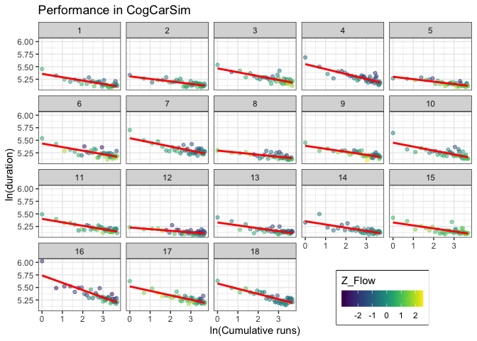

```r
meanZ = mean(fss$flow, na.rm = TRUE)
sdZ = sd(fss$flow, na.rm = TRUE)

fss %>% ggplot(aes(x = log(cumrun), y = log(duration), color = (flow-meanZ)/sdZ)) +
  geom_point(alpha = 0.5) +
  geom_smooth(method = "lm", formula = y~x, color = "red", se = FALSE)+
  facet_wrap(~participant) +
  scale_color_viridis(name = "Z_Flow", guide = guide_colorbar(direction = "horizontal", title.position = "top"), breaks = c(-2,-1,0,1,2)) +
  theme_bw() +
  labs(
    title = "Performance in CogCarSim",
    x = "ln(Cumulative runs)",
    y = "ln(duration)"
  ) +
  theme(
    legend.position = c(0.9, -0.05),
    legend.justification=c(1,0),
    legend.box.background = element_rect(colour = "black")
  )
```

I think it is close, but let’s check the instructions. Did not realize that the z_scores were participant wise. Let’s compute those and use those for the plot.

```r
fss <- fss %>% group_by(participant) %>% mutate(Z_Flow = (flow-mean(flow, na.rm = TRUE))/sd(flow, na.rm = TRUE)) %>% ungroup()
head(fss)
```

```
## # A tibble: 6 × 18
##   participant gender session   run collisions duration distance cumrun fluency
##         <dbl> <chr>    <dbl> <dbl>      <dbl>    <dbl>    <dbl>  <dbl>   <dbl>
## 1           1 male         1     1         26     234.   24197.      1    4.75
## 2           1 male         1     2         30     205.   24197.      2    4.5
## 3           1 male         1     3         20     190.   24199.      3    5.25
## 4           1 male         1     4         13     181.   24198.      4    5
## 5           1 male         1     5         18     189.   24198.      5    4.25
## 6           1 male         2     1         18     185.   24198.      6    4
## # … with 9 more variables: absorption <dbl>, flow <dbl>, pi1 <dbl>, pi2 <dbl>,
## #   pi3 <dbl>, comp1 <dbl>, comp2 <dbl>, comp3 <dbl>, Z_Flow <dbl>
```

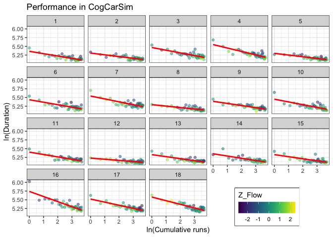

```r
fss %>% ggplot(aes(x = log(cumrun), y = log(duration), color = Z_Flow)) +
  geom_point(alpha = 0.5) +
  geom_smooth(method = "lm", formula = y~x, color = "red", se = FALSE)+
  facet_wrap(~participant) +
  scale_color_viridis(guide = guide_colorbar(direction = "horizontal", title.position = "top")) +
  theme_bw() +
  labs(
    title = "Performance in CogCarSim",
    x = "ln(Cumulative runs)",
    y = "ln(Duration)"
  ) +
  theme(
    legend.position = c(0.9, -0.05),
    legend.justification=c(1,0),
    legend.box.background = element_rect(colour = "black")
  )
```

Now it really is as close as possible. To make it identical would require tweaking image size, legend position etc.

I think, it is possible to make it bit more better. Firstly, as the points are colored by the z-scores it is better to use diverging color map. Similarly, I think the red line is bit too strong and distracting.

For the color map I’ll use the cool-warm color map from Moreland K. (2009) Diverging Color Maps for Scientific Visualization. In: Bebis G. et al. (eds) Advances in Visual Computing. ISVC 2009. Lecture Notes in Computer Science, vol 5876. Springer, Berlin, Heidelberg. https://doi.org/10.1007/978-3-642-10520-3_9

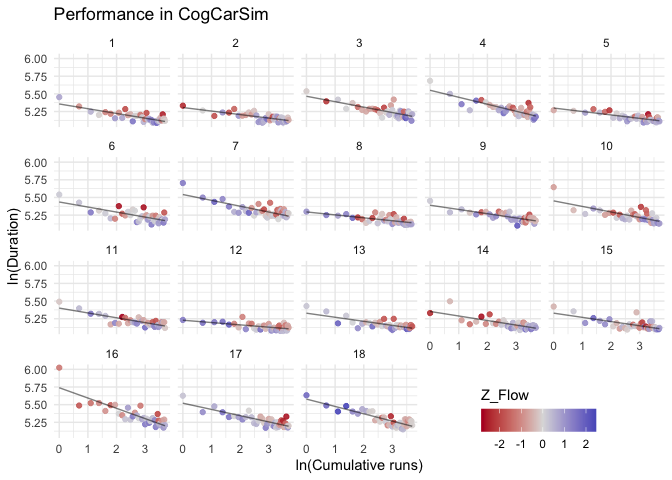

```r
fss %>% ggplot(aes(x = log(cumrun), y = log(duration), color = Z_Flow)) +
  geom_point(alpha = 0.9) +
  geom_line(stat = "smooth", method = "lm", formula = "y ~ x", color = "black", alpha = 0.5)+
  facet_wrap(~participant) +
  scale_color_gradient2(low="#b40426", mid="#dddddd", high="#3b4cc0", guide = guide_colorbar(direction = "horizontal", title.position = "top")) +
  theme_minimal() +
  labs(
    title = "Performance in CogCarSim",
    x = "ln(Cumulative runs)",
    y = "ln(Duration)"
  ) +
  theme(
    legend.position = c(0.9, -0.05),
    legend.justification=c(1,0)
  )
```

In my humble opinion this looks better than the original. Mainly, I think that the diverging color map makes interpreting the plot clearer as it is easier to differentiate the values below or above zero. I choose to use red for negative values as it feels bit more intuitive for the context. Similarly the black line does not clash some much with the points. Also, using the minimal theme makes the overall looks bit crispier.